# Multiclass Classification

Author

Alexa Marin

# Multiclass Classification

Our dataset consists of clinical data from patients who entered the hospital complaining of chest pain (“angina”) during exercise. The information collected includes:

- `age` : Age of the patient
- `sex` : Sex of the patient
- `cp` : Chest Pain type
  - Value 0: asymptomatic
  - Value 1: typical angina
  - Value 2: atypical angina
  - Value 3: non-anginal pain
- `trtbps` : resting blood pressure (in mm Hg)
- `chol` : cholesterol in mg/dl fetched via BMI sensor
- `restecg` : resting electrocardiographic results
  - Value 0: normal
  - Value 1: having ST-T wave abnormality (T wave inversions and/or ST elevation or depression of > 0.05 mV)
  - Value 2: showing probable or definite left ventricular hypertrophy by Estes’ criteria
- `thalach` : maximum heart rate achieved during exercise
- `output` : the doctor’s diagnosis of whether the patient is at risk for a heart attack
  - 0 = not at risk of heart attack
  - 1 = at risk of heart attack

```python
import numpy as np
import pandas as pd
import matplotlib.pyplot as plt
from io import StringIO
from IPython.display import display
from sklearn.pipeline import Pipeline
from sklearn.neighbors import KNeighborsClassifier
from sklearn.linear_model import LogisticRegression
from sklearn.preprocessing import StandardScaler
from sklearn.model_selection import StratifiedKFold, cross_val_predict, cross_val_score
from sklearn.metrics import accuracy_score, precision_score, recall_score, f1_score, classification_report

predictors = ["trtbps", "chol", "age"]
cv = StratifiedKFold(n_splits=5, shuffle=True, random_state=42)

def logistic_model():
    return Pipeline([
        ("scale", StandardScaler()),
        ("model", LogisticRegression(max_iter=2000, random_state=42))
    ])

def plot_predictions(frame, predicted, title, labels):
    fig, ax = plt.subplots(figsize=(8, 5))
    colors = plt.get_cmap("tab10")
    predicted = np.asarray(predicted).astype(str)
    for j, (value, label) in enumerate(labels.items()):
        selected = predicted == str(value)
        ax.scatter(frame.loc[selected, "trtbps"], frame.loc[selected, "chol"],
                   s=frame.loc[selected, "age"] * 1.6, alpha=0.55,
                   color=colors(j), label=label)
    ax.set(xlabel="Resting blood pressure (mm Hg)", ylabel="Cholesterol (mg/dL)", title=title)
    ax.legend(title="Class; point size = age", loc="best")
    fig.tight_layout()
    plt.show()
```

First we’ll create binary variables for each class.

```python
# Original course data embedded so the notebook runs without a download.
ha = pd.read_csv(StringIO('age,sex,cp,trtbps,chol,restecg,thalach,output\n63,1,3,145,233,0,150,1\n37,1,2,130,250,1,187,1\n56,1,1,120,236,1,178,1\n57,0,0,120,354,1,163,1\n57,1,0,140,192,1,148,1\n56,0,1,140,294,0,153,1\n44,1,1,120,263,1,173,1\n52,1,2,172,199,1,162,1\n57,1,2,150,168,1,174,1\n54,1,0,140,239,1,160,1\n48,0,2,130,275,1,139,1\n49,1,1,130,266,1,171,1\n58,0,3,150,283,0,162,1\n50,0,2,120,219,1,158,1\n58,0,2,120,340,1,172,1\n66,0,3,150,226,1,114,1\n43,1,0,150,247,1,171,1\n69,0,3,140,239,1,151,1\n44,1,2,130,233,1,179,1\n61,1,2,150,243,1,137,1\n71,0,1,160,302,1,162,1\n59,1,2,150,212,1,157,1\n51,1,2,110,175,1,123,1\n65,0,2,140,417,0,157,1\n53,1,2,130,197,0,152,1\n41,0,1,105,198,1,168,1\n65,1,0,120,177,1,140,1\n44,1,1,130,219,0,188,1\n51,1,3,125,213,0,125,1\n46,0,2,142,177,0,160,1\n54,0,2,135,304,1,170,1\n54,1,2,150,232,0,165,1\n65,0,2,155,269,1,148,1\n65,0,2,160,360,0,151,1\n51,0,2,140,308,0,142,1\n48,1,1,130,245,0,180,1\n45,1,0,104,208,0,148,1\n53,0,0,130,264,0,143,1\n39,1,2,140,321,0,182,1\n52,1,1,120,325,1,172,1\n44,1,2,140,235,0,180,1\n47,1,2,138,257,0,156,1\n53,0,2,128,216,0,115,1\n53,0,0,138,234,0,160,1\n51,0,2,130,256,0,149,1\n66,1,0,120,302,0,151,1\n62,1,2,130,231,1,146,1\n44,0,2,108,141,1,175,1\n63,0,2,135,252,0,172,1\n48,1,0,122,222,0,186,1\n45,1,0,115,260,0,185,1\n34,1,3,118,182,0,174,1\n57,0,0,128,303,0,159,1\n54,1,1,108,309,1,156,1\n52,1,3,118,186,0,190,1\n41,1,1,135,203,1,132,1\n58,1,2,140,211,0,165,1\n35,0,0,138,183,1,182,1\n51,1,2,100,222,1,143,1\n45,0,1,130,234,0,175,1\n44,1,1,120,220,1,170,1\n62,0,0,124,209,1,163,1\n54,1,2,120,258,0,147,1\n51,1,2,94,227,1,154,1\n29,1,1,130,204,0,202,1\n51,1,0,140,261,0,186,1\n43,0,2,122,213,1,165,1\n51,1,2,125,245,0,166,1\n59,1,1,140,221,1,164,1\n52,1,1,128,205,1,184,1\n41,1,2,112,250,1,179,1\n45,1,1,128,308,0,170,1\n60,0,2,102,318,1,160,1\n52,1,3,152,298,1,178,1\n42,0,0,102,265,0,122,1\n67,0,2,115,564,0,160,1\n54,0,2,110,214,1,158,1\n58,0,0,100,248,0,122,1\n57,1,0,132,207,1,168,1\n52,1,2,138,223,1,169,1\n54,0,1,132,288,0,159,1\n45,0,1,112,160,1,138,1\n53,1,0,142,226,0,111,1\n62,0,0,140,394,0,157,1\n52,1,0,108,233,1,147,1\n43,1,2,130,315,1,162,1\n42,1,3,148,244,0,178,1\n59,1,3,178,270,0,145,1\n63,0,1,140,195,1,179,1\n42,1,2,120,240,1,194,1\n50,1,2,129,196,1,163,1\n68,0,2,120,211,0,115,1\n45,0,0,138,236,0,152,1\n64,0,0,180,325,1,154,1\n57,1,2,150,126,1,173,1\n64,0,2,140,313,1,133,1\n43,1,0,110,211,1,161,1\n55,1,1,130,262,1,155,1\n37,0,2,120,215,1,170,1\n41,1,2,130,214,0,168,1\n56,1,3,120,193,0,162,1\n46,0,1,105,204,1,172,1\n46,0,0,138,243,0,152,1\n64,0,0,130,303,1,122,1\n41,0,2,112,268,0,172,1\n54,0,2,108,267,0,167,1\n39,0,2,94,199,1,179,1\n34,0,1,118,210,1,192,1\n67,0,2,152,277,1,172,1\n52,0,2,136,196,0,169,1\n74,0,1,120,269,0,121,1\n54,0,2,160,201,1,163,1\n49,0,1,134,271,1,162,1\n42,1,1,120,295,1,162,1\n41,1,1,110,235,1,153,1\n41,0,1,126,306,1,163,1\n49,0,0,130,269,1,163,1\n60,0,2,120,178,1,96,1\n62,1,1,128,208,0,140,1\n57,1,0,110,201,1,126,1\n64,1,0,128,263,1,105,1\n51,0,2,120,295,0,157,1\n43,1,0,115,303,1,181,1\n42,0,2,120,209,1,173,1\n67,0,0,106,223,1,142,1\n76,0,2,140,197,2,116,1\n70,1,1,156,245,0,143,1\n44,0,2,118,242,1,149,1\n60,0,3,150,240,1,171,1\n44,1,2,120,226,1,169,1\n42,1,2,130,180,1,150,1\n66,1,0,160,228,0,138,1\n71,0,0,112,149,1,125,1\n64,1,3,170,227,0,155,1\n66,0,2,146,278,0,152,1\n39,0,2,138,220,1,152,1\n58,0,0,130,197,1,131,1\n47,1,2,130,253,1,179,1\n35,1,1,122,192,1,174,1\n58,1,1,125,220,1,144,1\n56,1,1,130,221,0,163,1\n56,1,1,120,240,1,169,1\n55,0,1,132,342,1,166,1\n41,1,1,120,157,1,182,1\n38,1,2,138,175,1,173,1\n38,1,2,138,175,1,173,1\n67,1,0,160,286,0,108,0\n67,1,0,120,229,0,129,0\n62,0,0,140,268,0,160,0\n63,1,0,130,254,0,147,0\n53,1,0,140,203,0,155,0\n56,1,2,130,256,0,142,0\n48,1,1,110,229,1,168,0\n58,1,2,132,224,0,173,0\n60,1,0,130,206,0,132,0\n40,1,0,110,167,0,114,0\n60,1,0,117,230,1,160,0\n64,1,2,140,335,1,158,0\n43,1,0,120,177,0,120,0\n57,1,0,150,276,0,112,0\n55,1,0,132,353,1,132,0\n65,0,0,150,225,0,114,0\n58,1,2,112,230,0,165,0\n50,1,0,150,243,0,128,0\n44,1,0,112,290,0,153,0\n60,1,0,130,253,1,144,0\n54,1,0,124,266,0,109,0\n50,1,2,140,233,1,163,0\n41,1,0,110,172,0,158,0\n51,0,0,130,305,1,142,0\n58,1,0,128,216,0,131,0\n54,1,0,120,188,1,113,0\n60,1,0,145,282,0,142,0\n60,1,2,140,185,0,155,0\n59,1,0,170,326,0,140,0\n46,1,2,150,231,1,147,0\n67,1,0,125,254,1,163,0\n62,1,0,120,267,1,99,0\n65,1,0,110,248,0,158,0\n44,1,0,110,197,0,177,0\n60,1,0,125,258,0,141,0\n58,1,0,150,270,0,111,0\n68,1,2,180,274,0,150,0\n52,1,0,128,255,1,161,0\n59,1,0,110,239,0,142,0\n60,0,0,150,258,0,157,0\n49,1,2,120,188,1,139,0\n57,1,2,128,229,0,150,0\n61,1,0,120,260,1,140,0\n39,1,0,118,219,1,140,0\n61,0,0,145,307,0,146,0\n56,1,0,125,249,0,144,0\n43,0,0,132,341,0,136,0\n62,0,2,130,263,1,97,0\n63,1,0,130,330,0,132,0\n65,1,0,135,254,0,127,0\n63,0,0,150,407,0,154,0\n65,1,3,138,282,0,174,0\n56,0,0,200,288,0,133,0\n54,1,0,110,239,1,126,0\n70,1,0,145,174,1,125,0\n62,1,1,120,281,0,103,0\n35,1,0,120,198,1,130,0\n59,1,3,170,288,0,159,0\n64,1,2,125,309,1,131,0\n47,1,2,108,243,1,152,0\n57,1,0,165,289,0,124,0\n55,1,0,160,289,0,145,0\n64,1,0,120,246,0,96,0\n70,1,0,130,322,0,109,0\n51,1,0,140,299,1,173,0\n58,1,0,125,300,0,171,0\n60,1,0,140,293,0,170,0\n77,1,0,125,304,0,162,0\n35,1,0,126,282,0,156,0\n70,1,2,160,269,1,112,0\n59,0,0,174,249,1,143,0\n64,1,0,145,212,0,132,0\n57,1,0,152,274,1,88,0\n56,1,0,132,184,0,105,0\n48,1,0,124,274,0,166,0\n56,0,0,134,409,0,150,0\n66,1,1,160,246,1,120,0\n54,1,1,192,283,0,195,0\n69,1,2,140,254,0,146,0\n43,1,0,132,247,0,143,0\n62,0,0,138,294,1,106,0\n59,1,3,160,273,0,125,0\n58,1,0,128,259,0,130,0\n50,1,0,144,200,0,126,0\n62,0,0,150,244,1,154,0\n38,1,3,120,231,1,182,0\n66,0,0,178,228,1,165,0\n52,1,0,112,230,1,160,0\n53,1,0,123,282,1,95,0\n63,0,0,108,269,1,169,0\n54,1,0,110,206,0,108,0\n66,1,0,112,212,0,132,0\n55,0,0,180,327,2,117,0\n49,1,2,118,149,0,126,0\n54,1,0,122,286,0,116,0\n56,1,0,130,283,0,103,0\n46,1,0,120,249,0,144,0\n61,1,3,134,234,1,145,0\n67,1,0,120,237,1,71,0\n58,1,0,100,234,1,156,0\n52,1,0,125,212,1,168,0\n58,1,0,146,218,1,105,0\n57,1,1,124,261,1,141,0\n58,0,1,136,319,0,152,0\n61,1,0,138,166,0,125,0\n42,1,0,136,315,1,125,0\n52,1,0,128,204,1,156,0\n59,1,2,126,218,1,134,0\n40,1,0,152,223,1,181,0\n61,1,0,140,207,0,138,0\n46,1,0,140,311,1,120,0\n59,1,3,134,204,1,162,0\n57,1,1,154,232,0,164,0\n57,1,0,110,335,1,143,0\n55,0,0,128,205,2,130,0\n61,1,0,148,203,1,161,0\n58,1,0,114,318,2,140,0\n58,0,0,170,225,0,146,0\n67,1,2,152,212,0,150,0\n44,1,0,120,169,1,144,0\n63,1,0,140,187,0,144,0\n63,0,0,124,197,1,136,0\n59,1,0,164,176,0,90,0\n57,0,0,140,241,1,123,0\n45,1,3,110,264,1,132,0\n68,1,0,144,193,1,141,0\n57,0,1,130,236,0,174,0\n'))

for category in range(4):
    ha[f"cp_is_{category}"] = (ha["cp"] == category).astype(int)

ha["cp"] = ha["cp"].astype(str)
X = ha[predictors]
y = ha["cp"]
ha
```

|  | age | sex | cp | trtbps | chol | restecg | thalach | output | cp_is_0 | cp_is_1 | cp_is_2 | cp_is_3 |
| --- | --- | --- | --- | --- | --- | --- | --- | --- | --- | --- | --- | --- |
| 0 | 63 | 1 | 3 | 145 | 233 | 0 | 150 | 1 | 0 | 0 | 0 | 1 |
| 1 | 37 | 1 | 2 | 130 | 250 | 1 | 187 | 1 | 0 | 0 | 1 | 0 |
| 2 | 56 | 1 | 1 | 120 | 236 | 1 | 178 | 1 | 0 | 1 | 0 | 0 |
| 3 | 57 | 0 | 0 | 120 | 354 | 1 | 163 | 1 | 1 | 0 | 0 | 0 |
| 4 | 57 | 1 | 0 | 140 | 192 | 1 | 148 | 1 | 1 | 0 | 0 | 0 |
| ... | ... | ... | ... | ... | ... | ... | ... | ... | ... | ... | ... | ... |
| 268 | 59 | 1 | 0 | 164 | 176 | 0 | 90 | 0 | 1 | 0 | 0 | 0 |
| 269 | 57 | 0 | 0 | 140 | 241 | 1 | 123 | 0 | 1 | 0 | 0 | 0 |
| 270 | 45 | 1 | 3 | 110 | 264 | 1 | 132 | 0 | 0 | 0 | 0 | 1 |
| 271 | 68 | 1 | 0 | 144 | 193 | 1 | 141 | 0 | 1 | 0 | 0 | 0 |
| 272 | 57 | 0 | 1 | 130 | 236 | 0 | 174 | 0 | 0 | 1 | 0 | 0 |

273 rows × 12 columns

The target is `cp` which has 4 categories. How common is each category?

```python
ha["cp"].value_counts().sort_index()
```

```
cp
0    128
1     44
2     81
3     20
Name: count, dtype: int64
```

Let’s consider as predictors: `trtbps`, `chol`, `age`.

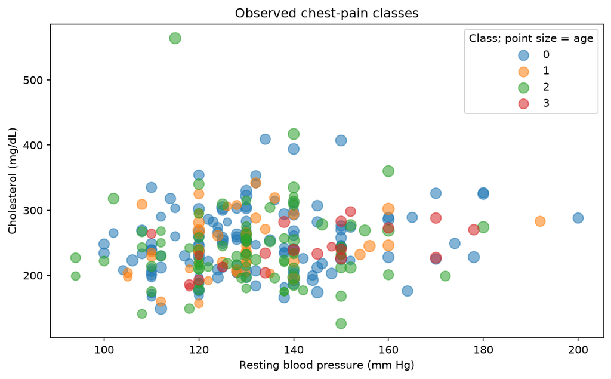

```python
plot_predictions(ha, y, "Observed chest-pain classes", {str(k): str(k) for k in range(4)})
```

**How the models are checked:** I use resting blood pressure, cholesterol, and age for every model. Test estimates come from five stratified folds with a fixed seed of 42. Scaling is fitted inside each training fold to avoid data leakage. The probability tables and plots use the full training data; the reported scores use held-out predictions. For accuracy, precision, recall, and F1, I combine the held-out predictions across the five folds. For ROC-AUC, I report the mean of the five test-fold AUCs. Logistic regression uses the usual 0.5 cutoff. Macro scores give each class equal weight. All scores are on a 0–1 scale.

## Q1: A Natural Multiclass Model: k-nearest neighbors

Fit a multiclass 10-nearest neighbors model. Output the predicted class probabilities and plot the predicted classes for the training data. Estimate the test:

- accuracy
- macro precision, recall, and F1 scores
- precision, recall, and F1 score for each class. You will likely get some weird values; can you explain why?

```
Q1: Predicted training probabilities (all patients stored in knn_probabilities)
```

|  | P(cp=0) | P(cp=1) | P(cp=2) | P(cp=3) |
| --- | --- | --- | --- | --- |
| 0 | 0.5 | 0.1 | 0.1 | 0.3 |
| 1 | 0.2 | 0.1 | 0.6 | 0.1 |
| 2 | 0.2 | 0.5 | 0.3 | 0.0 |
| 3 | 0.7 | 0.2 | 0.1 | 0.0 |
| 4 | 0.6 | 0.1 | 0.2 | 0.1 |
| ... | ... | ... | ... | ... |
| 268 | 0.3 | 0.1 | 0.5 | 0.1 |
| 269 | 0.5 | 0.2 | 0.2 | 0.1 |
| 270 | 0.4 | 0.1 | 0.4 | 0.1 |
| 271 | 0.7 | 0.1 | 0.1 | 0.1 |
| 272 | 0.3 | 0.3 | 0.4 | 0.0 |

273 rows × 4 columns

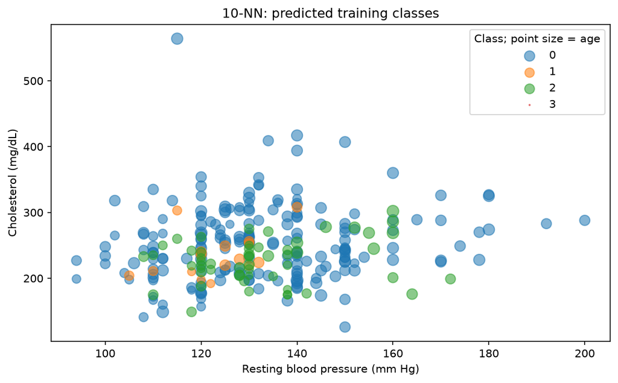

```
Q1 ANSWER: Estimated test performance
```

|  | Out-of-fold test estimate |
| --- | --- |
| Accuracy | 0.4103 |
| Macro precision | 0.2105 |
| Macro recall | 0.2375 |
| Macro F1 | 0.2047 |

```
Q1 ANSWER: Precision, recall, F1, and support for each class
```

|  | precision | recall | f1-score | support |
| --- | --- | --- | --- | --- |
| 0 | 0.4831 | 0.7812 | 0.5970 | 128.0 |
| 1 | 0.1667 | 0.0455 | 0.0714 | 44.0 |
| 2 | 0.1923 | 0.1235 | 0.1504 | 81.0 |
| 3 | 0.0000 | 0.0000 | 0.0000 | 20.0 |

```
Out-of-fold predicted class counts:
```

```
0    207
1     12
2     52
3      2
Name: count, dtype: int64
```

```python
knn = Pipeline([
    ("scale", StandardScaler()),
    ("model", KNeighborsClassifier(n_neighbors=10))
])
knn.fit(X, y)

# These probabilities and the plot describe the fitted training data.
knn_probabilities = pd.DataFrame(
    knn.predict_proba(X), columns=[f"P(cp={k})" for k in knn.classes_], index=ha.index
)
print("Q1: Predicted training probabilities (all patients stored in knn_probabilities)")
display(knn_probabilities)
plot_predictions(ha, knn.predict(X), "10-NN: predicted training classes", {str(k): str(k) for k in range(4)})

# Each patient is predicted by a model trained on the other four folds.
knn_oof = cross_val_predict(knn, X, y, cv=cv, method="predict")
q1_metrics = pd.Series({
    "Accuracy": accuracy_score(y, knn_oof),
    "Macro precision": precision_score(y, knn_oof, average="macro", zero_division=0),
    "Macro recall": recall_score(y, knn_oof, average="macro", zero_division=0),
    "Macro F1": f1_score(y, knn_oof, average="macro", zero_division=0)
}, name="Out-of-fold test estimate")
print("Q1 ANSWER: Estimated test performance")
display(q1_metrics.to_frame().round(4))
q1_report = pd.DataFrame(classification_report(
    y, knn_oof, labels=["0", "1", "2", "3"], output_dict=True, zero_division=0
)).T
print("Q1 ANSWER: Precision, recall, F1, and support for each class")
display(q1_report.loc[["0", "1", "2", "3"]].round(4))
print("Out-of-fold predicted class counts:")
display(pd.Series(knn_oof).value_counts().reindex(["0", "1", "2", "3"], fill_value=0))
```

**Q1 Answer:** The estimated test accuracy is 0.4103. Macro precision is 0.2105, macro recall is 0.2375, and macro F1 is 0.2047. The table above gives the scores for each class. The classes are uneven: class 0 has 128 patients, class 1 has 44, class 2 has 81, and class 3 has only 20. With 10 neighbors, a rare class can lose the vote to more common classes, especially when the predictors overlap. If a class is never predicted, its precision is undefined because there are no predicted positives. I report it as 0 using `zero_division=0`. Its recall and F1 are also 0 when none of its actual cases are identified. These zero scores do not mean the class is missing from the data.

## Q2: OvR for Class 3

Fit a logistic regression model for predicting Class 3. Output the predicted class probabilities (Class 3 or not) and plot the predicted classes (Class 3 or not) for the training data. Estimate the test:

- precision, recall, and F1 score for class 3

```
Class 3: predicted training probabilities
```

|  | P(not 3) | P(class 3) |
| --- | --- | --- |
| 0 | 0.901104 | 0.098896 |
| 1 | 0.941224 | 0.058776 |
| 2 | 0.951037 | 0.048963 |
| 3 | 0.971022 | 0.028978 |
| 4 | 0.898105 | 0.101895 |
| ... | ... | ... |
| 268 | 0.801764 | 0.198236 |
| 269 | 0.917096 | 0.082904 |
| 270 | 0.967963 | 0.032037 |
| 271 | 0.885371 | 0.114629 |
| 272 | 0.935386 | 0.064614 |

273 rows × 2 columns

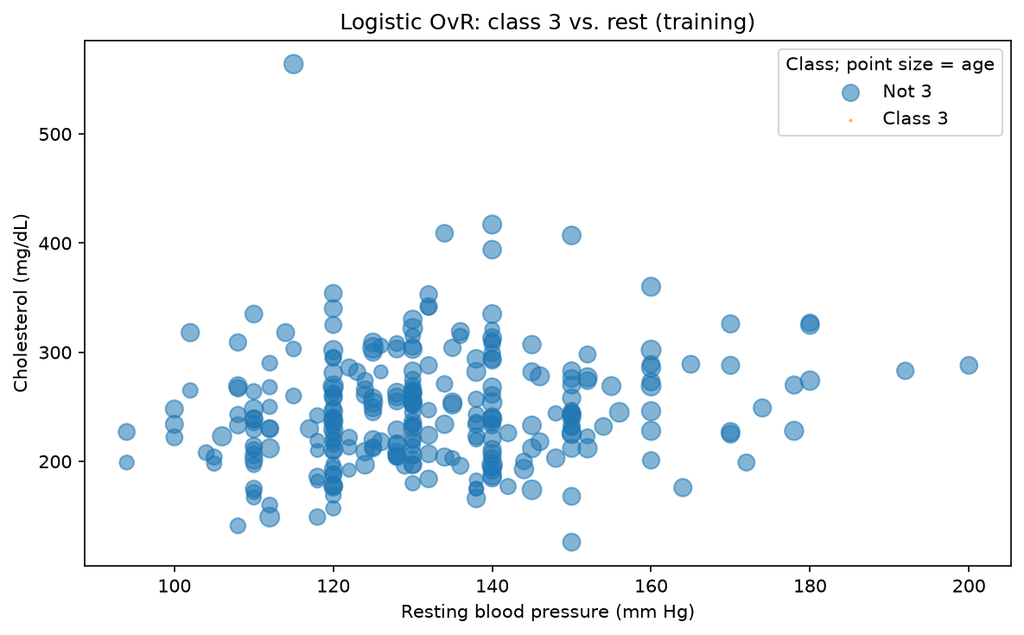

```
Q2 ANSWER: Class 3 estimated test scores
```

| Class | Precision | Recall | F1 | Actual positives | Predicted positives |
| --- | --- | --- | --- | --- | --- |
| 3 | 0.0 | 0.0 | 0.0 | 20 | 0 |

```python
def fit_ovr(category):
    target = ha[f"cp_is_{category}"]
    model = logistic_model()
    model.fit(X, target)
    probabilities = pd.DataFrame(
        model.predict_proba(X),
        columns=[f"P(not {category})", f"P(class {category})"], index=ha.index
    )
    print(f"Class {category}: predicted training probabilities")
    display(probabilities)
    plot_predictions(ha, model.predict(X), f"Logistic OvR: class {category} vs. rest (training)",
                     {0: f"Not {category}", 1: f"Class {category}"})
    predicted = cross_val_predict(model, X, target, cv=cv, method="predict")
    metrics = {
        "Class": str(category),
        "Precision": precision_score(target, predicted, pos_label=1, zero_division=0),
        "Recall": recall_score(target, predicted, pos_label=1, zero_division=0),
        "F1": f1_score(target, predicted, pos_label=1, zero_division=0),
        "Actual positives": int(target.sum()),
        "Predicted positives": int(predicted.sum())
    }
    return model, probabilities, metrics

ovr_models, ovr_probabilities, ovr_metrics = {}, {}, {}
ovr_models[3], ovr_probabilities[3], ovr_metrics[3] = fit_ovr(3)
print("Q2 ANSWER: Class 3 estimated test scores")
display(pd.DataFrame([ovr_metrics[3]]).set_index("Class").round(4))
```

**Q2 Answer:** For class 3, estimated test precision is 0.0000, recall is 0.0000, and F1 is 0.0000. The model predicts class 3 for 0 patients in the held-out predictions. At the 0.5 cutoff, it does not identify the class 3 cases. The class is rare, and these three predictors do not separate it well enough for this fitted model to classify patients as class 3.

## Q3: OvR - Other classes.

Repeat Q2 for each of the other three `cp` categories. Which category was the OvR approach best at distinguishing?

```
Class 0: predicted training probabilities
```

|  | P(not 0) | P(class 0) |
| --- | --- | --- |
| 0 | 0.478092 | 0.521908 |
| 1 | 0.678292 | 0.321708 |
| 2 | 0.504099 | 0.495901 |
| 3 | 0.443054 | 0.556946 |
| 4 | 0.543651 | 0.456349 |
| ... | ... | ... |
| 268 | 0.567364 | 0.432636 |
| 269 | 0.522096 | 0.477904 |
| 270 | 0.577090 | 0.422910 |
| 271 | 0.448706 | 0.551294 |
| 272 | 0.509632 | 0.490368 |

273 rows × 2 columns

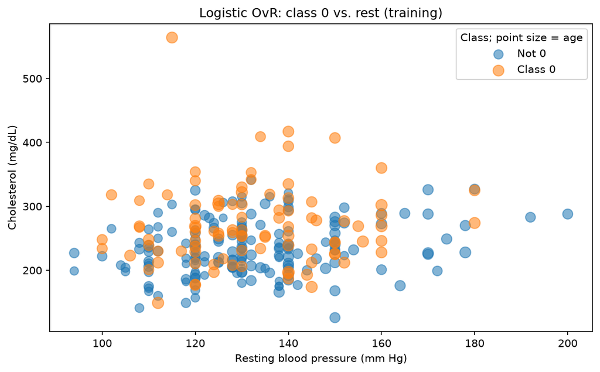

```
Class 1: predicted training probabilities
```

|  | P(not 1) | P(class 1) |
| --- | --- | --- |
| 0 | 0.894867 | 0.105133 |
| 1 | 0.734949 | 0.265051 |
| 2 | 0.845941 | 0.154059 |
| 3 | 0.820938 | 0.179062 |
| 4 | 0.876054 | 0.123946 |
| ... | ... | ... |
| 268 | 0.902109 | 0.097891 |
| 269 | 0.865861 | 0.134139 |
| 270 | 0.762384 | 0.237616 |
| 271 | 0.916776 | 0.083224 |
| 272 | 0.859079 | 0.140921 |

273 rows × 2 columns

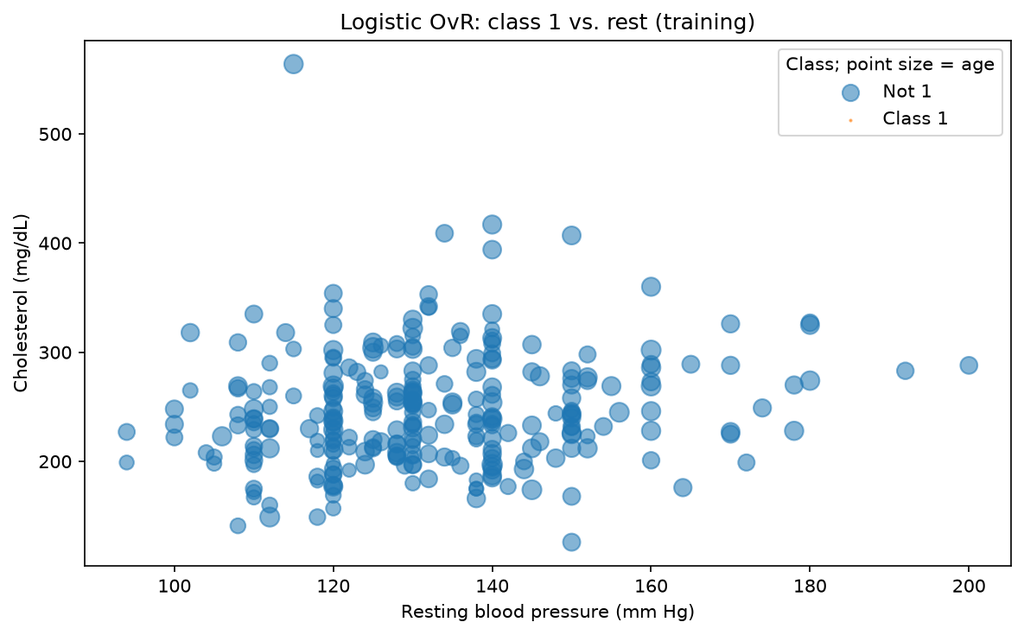

```
Class 2: predicted training probabilities
```

|  | P(not 2) | P(class 2) |
| --- | --- | --- |
| 0 | 0.731442 | 0.268558 |
| 1 | 0.638588 | 0.361412 |
| 2 | 0.706497 | 0.293503 |
| 3 | 0.753821 | 0.246179 |
| 4 | 0.693586 | 0.306414 |
| ... | ... | ... |
| 268 | 0.695694 | 0.304306 |
| 269 | 0.712897 | 0.287103 |
| 270 | 0.675674 | 0.324326 |
| 271 | 0.734003 | 0.265997 |
| 272 | 0.710564 | 0.289436 |

273 rows × 2 columns

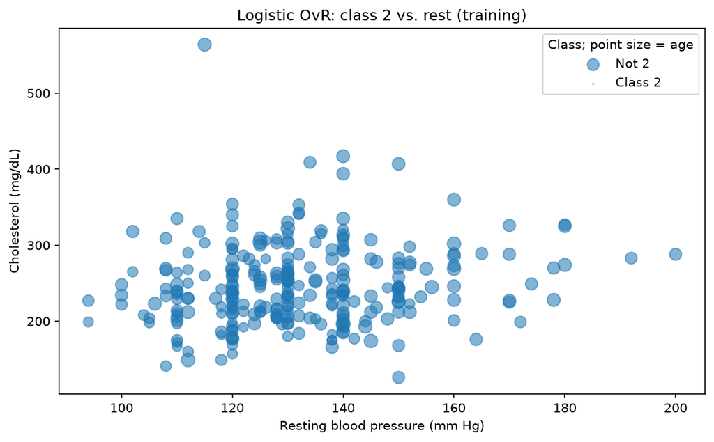

```
Q3 ANSWER: OvR test estimates (positive class = the named chest-pain category)
```

| Class | Precision | Recall | F1 | Actual positives | Predicted positives |
| --- | --- | --- | --- | --- | --- |
| 0 | 0.5545 | 0.4375 | 0.4891 | 128 | 101 |
| 1 | 0.0000 | 0.0000 | 0.0000 | 44 | 0 |
| 2 | 0.0000 | 0.0000 | 0.0000 | 81 | 0 |
| 3 | 0.0000 | 0.0000 | 0.0000 | 20 | 0 |

```
Best OvR category by F1: 0
```

```python
for category in [0, 1, 2]:
    ovr_models[category], ovr_probabilities[category], ovr_metrics[category] = fit_ovr(category)

ovr_results = pd.DataFrame([ovr_metrics[k] for k in range(4)]).set_index("Class")
print("Q3 ANSWER: OvR test estimates (positive class = the named chest-pain category)")
display(ovr_results.round(4))
print(f"Best OvR category by F1: {ovr_results['F1'].idxmax()}")
```

**Q3 Answer:** The OvR model is best at distinguishing class 0, based on its highest estimated test F1 of 0.4891. I use F1 because it considers both precision and recall for the class being identified. Class 0 is the largest group, which can help the model learn it. The other classes are harder to identify using only blood pressure, cholesterol, and age.

## Q4: OvO

Reduce your dataset to only the `0` and `1` types of chest pain.

Then, fit a Logistic Regression to predict between the two groups, and estimate the ROC-AUC.

```python
def compare_pair(other):
    pair = ha.loc[ha["cp"].isin(["0", str(other)])].copy()
    pair_X = pair[predictors]
    # The nonzero category is the positive class for ROC-AUC.
    pair_y = (pair["cp"] == str(other)).astype(int)
    model = logistic_model()
    aucs = cross_val_score(model, pair_X, pair_y, cv=cv, scoring="roc_auc")
    model.fit(pair_X, pair_y)
    result = {
        "Pair": f"0 vs {other}", "Patients": len(pair),
        "Mean test ROC-AUC": aucs.mean(), "Fold SD": aucs.std(ddof=1)
    }
    return model, result, aucs

ovo_models, ovo_metrics, ovo_fold_aucs = {}, {}, {}
ovo_models[1], ovo_metrics[1], ovo_fold_aucs[1] = compare_pair(1)
print("Q4 ANSWER: Class 0 vs. class 1")
display(pd.DataFrame([ovo_metrics[1]]).set_index("Pair").round(4))
print("ROC-AUC by test fold:", np.round(ovo_fold_aucs[1], 4))
```

```
Q4 ANSWER: Class 0 vs. class 1
```

| Pair | Patients | Mean test ROC-AUC | Fold SD |
| --- | --- | --- | --- |
| 0 vs 1 | 172 | 0.6276 | 0.0921 |

```
ROC-AUC by test fold: [0.6624 0.5513 0.7733 0.5644 0.5865]
```

**Q4 Answer:** For class 0 versus class 1, the estimated test ROC-AUC is 0.6276. Class 1 is the positive class. AUC measures how well predicted probabilities rank positive cases above negative cases across possible cutoffs; 0.5 indicates chance-level ranking.

## Q5: OvO

Repeat Q4 comparing category `0` to `2`, and again to compare category `0` to `3`. Which pair was the OvO approach best at distinguishing?

```python
for other in [2, 3]:
    ovo_models[other], ovo_metrics[other], ovo_fold_aucs[other] = compare_pair(other)

ovo_results = pd.DataFrame([ovo_metrics[k] for k in [1, 2, 3]]).set_index("Pair")
print("Q5 ANSWER: Pairwise logistic regression test ROC-AUC")
display(ovo_results.round(4))
print(f"Best pair by mean test ROC-AUC: {ovo_results['Mean test ROC-AUC'].idxmax()}")
```

```
Q5 ANSWER: Pairwise logistic regression test ROC-AUC
```

| Pair | Patients | Mean test ROC-AUC | Fold SD |
| --- | --- | --- | --- |
| 0 vs 1 | 172 | 0.6276 | 0.0921 |
| 0 vs 2 | 209 | 0.5777 | 0.1475 |
| 0 vs 3 | 148 | 0.6009 | 0.1506 |

```
Best pair by mean test ROC-AUC: 0 vs 1
```

**Q5 Answer:** The estimated test ROC-AUC is 0.5777 for class 0 versus class 2 and 0.6009 for class 0 versus class 3. The model distinguishes 0 vs 1 best, with the highest mean test ROC-AUC of 0.6276. These AUCs are fairly close to 0.5, so even the best pair has limited separation using these predictors. The fold SD shows how much the AUC changes across the five test folds.